# Risk Factor Analysis

## Outcome Variable

**Outcome Variable:** ever_wasted

## Predictor Variables

**Intervention Variable:** impsan

**Adjustment Set:**

unadjusted

## Stratifying Variables

The analysis was stratified on these variable(s):

- agecat
- studyid
- country

## Data Summary

| agecat | studyid | country | impsan | ever_wasted | n_cell | n |
| --- | --- | --- | --- | --- | --- | --- |
| 0-24 months (no birth wast) | ki0047075b-MAL-ED | BANGLADESH | 1 | 0 | 157 | 242 |
| 0-24 months (no birth wast) | ki0047075b-MAL-ED | BANGLADESH | 1 | 1 | 47 | 242 |
| 0-24 months (no birth wast) | ki0047075b-MAL-ED | BANGLADESH | 0 | 0 | 28 | 242 |
| 0-24 months (no birth wast) | ki0047075b-MAL-ED | BANGLADESH | 0 | 1 | 10 | 242 |
| 0-24 months (no birth wast) | ki0047075b-MAL-ED | BRAZIL | 1 | 0 | 193 | 209 |
| 0-24 months (no birth wast) | ki0047075b-MAL-ED | BRAZIL | 1 | 1 | 12 | 209 |
| 0-24 months (no birth wast) | ki0047075b-MAL-ED | BRAZIL | 0 | 0 | 4 | 209 |
| 0-24 months (no birth wast) | ki0047075b-MAL-ED | BRAZIL | 0 | 1 | 0 | 209 |
| 0-24 months (no birth wast) | ki0047075b-MAL-ED | INDIA | 1 | 0 | 75 | 229 |
| 0-24 months (no birth wast) | ki0047075b-MAL-ED | INDIA | 1 | 1 | 30 | 229 |
| 0-24 months (no birth wast) | ki0047075b-MAL-ED | INDIA | 0 | 0 | 69 | 229 |
| 0-24 months (no birth wast) | ki0047075b-MAL-ED | INDIA | 0 | 1 | 55 | 229 |
| 0-24 months (no birth wast) | ki0047075b-MAL-ED | NEPAL | 1 | 0 | 190 | 236 |
| 0-24 months (no birth wast) | ki0047075b-MAL-ED | NEPAL | 1 | 1 | 45 | 236 |
| 0-24 months (no birth wast) | ki0047075b-MAL-ED | NEPAL | 0 | 0 | 1 | 236 |
| 0-24 months (no birth wast) | ki0047075b-MAL-ED | NEPAL | 0 | 1 | 0 | 236 |
| 0-24 months (no birth wast) | ki0047075b-MAL-ED | PERU | 1 | 0 | 59 | 263 |
| 0-24 months (no birth wast) | ki0047075b-MAL-ED | PERU | 1 | 1 | 6 | 263 |
| 0-24 months (no birth wast) | ki0047075b-MAL-ED | PERU | 0 | 0 | 184 | 263 |
| 0-24 months (no birth wast) | ki0047075b-MAL-ED | PERU | 0 | 1 | 14 | 263 |
| 0-24 months (no birth wast) | ki0047075b-MAL-ED | SOUTH AFRICA | 1 | 0 | 3 | 250 |
| 0-24 months (no birth wast) | ki0047075b-MAL-ED | SOUTH AFRICA | 1 | 1 | 1 | 250 |
| 0-24 months (no birth wast) | ki0047075b-MAL-ED | SOUTH AFRICA | 0 | 0 | 204 | 250 |
| 0-24 months (no birth wast) | ki0047075b-MAL-ED | SOUTH AFRICA | 0 | 1 | 42 | 250 |
| 0-24 months (no birth wast) | ki0047075b-MAL-ED | TANZANIA, UNITED REPUBLIC OF | 1 | 0 | 0 | 241 |
| 0-24 months (no birth wast) | ki0047075b-MAL-ED | TANZANIA, UNITED REPUBLIC OF | 1 | 1 | 0 | 241 |
| 0-24 months (no birth wast) | ki0047075b-MAL-ED | TANZANIA, UNITED REPUBLIC OF | 0 | 0 | 212 | 241 |
| 0-24 months (no birth wast) | ki0047075b-MAL-ED | TANZANIA, UNITED REPUBLIC OF | 0 | 1 | 29 | 241 |
| 0-24 months (no birth wast) | ki1017093-NIH-Birth | BANGLADESH | 1 | 0 | 180 | 598 |
| 0-24 months (no birth wast) | ki1017093-NIH-Birth | BANGLADESH | 1 | 1 | 53 | 598 |

[output cut: 174 more lines]

The following strata were considered:

- agecat: 0-24 months (no birth wast), studyid: ki0047075b-MAL-ED, country: BANGLADESH
- agecat: 0-24 months (no birth wast), studyid: ki0047075b-MAL-ED, country: BRAZIL
- agecat: 0-24 months (no birth wast), studyid: ki0047075b-MAL-ED, country: INDIA
- agecat: 0-24 months (no birth wast), studyid: ki0047075b-MAL-ED, country: NEPAL
- agecat: 0-24 months (no birth wast), studyid: ki0047075b-MAL-ED, country: PERU
- agecat: 0-24 months (no birth wast), studyid: ki0047075b-MAL-ED, country: SOUTH AFRICA
- agecat: 0-24 months (no birth wast), studyid: ki0047075b-MAL-ED, country: TANZANIA, UNITED REPUBLIC OF
- agecat: 0-24 months (no birth wast), studyid: ki1017093-NIH-Birth, country: BANGLADESH
- agecat: 0-24 months (no birth wast), studyid: ki1017093b-PROVIDE, country: BANGLADESH
- agecat: 0-24 months (no birth wast), studyid: ki1017093c-NIH-Crypto, country: BANGLADESH
- agecat: 0-24 months (no birth wast), studyid: ki1114097-CONTENT, country: PERU
- agecat: 0-24 months (no birth wast), studyid: ki1135781-COHORTS, country: GUATEMALA
- agecat: 0-24 months (no birth wast), studyid: ki1135781-COHORTS, country: INDIA
- agecat: 0-24 months (no birth wast), studyid: ki1135781-COHORTS, country: PHILIPPINES
- agecat: 0-24 months (no birth wast), studyid: ki1148112-LCNI-5, country: MALAWI
- agecat: 0-24 months (no birth wast), studyid: kiGH5241-JiVitA-3, country: BANGLADESH
- agecat: 0-24 months (no birth wast), studyid: kiGH5241-JiVitA-4, country: BANGLADESH
- agecat: 0-6 months (no birth wast), studyid: ki0047075b-MAL-ED, country: BANGLADESH
- agecat: 0-6 months (no birth wast), studyid: ki0047075b-MAL-ED, country: BRAZIL
- agecat: 0-6 months (no birth wast), studyid: ki0047075b-MAL-ED, country: INDIA
- agecat: 0-6 months (no birth wast), studyid: ki0047075b-MAL-ED, country: NEPAL
- agecat: 0-6 months (no birth wast), studyid: ki0047075b-MAL-ED, country: PERU
- agecat: 0-6 months (no birth wast), studyid: ki0047075b-MAL-ED, country: SOUTH AFRICA
- agecat: 0-6 months (no birth wast), studyid: ki0047075b-MAL-ED, country: TANZANIA, UNITED REPUBLIC OF
- agecat: 0-6 months (no birth wast), studyid: ki1017093-NIH-Birth, country: BANGLADESH
- agecat: 0-6 months (no birth wast), studyid: ki1017093b-PROVIDE, country: BANGLADESH
- agecat: 0-6 months (no birth wast), studyid: ki1017093c-NIH-Crypto, country: BANGLADESH
- agecat: 0-6 months (no birth wast), studyid: ki1114097-CONTENT, country: PERU
- agecat: 0-6 months (no birth wast), studyid: ki1135781-COHORTS, country: GUATEMALA
- agecat: 0-6 months (no birth wast), studyid: ki1135781-COHORTS, country: INDIA
- agecat: 0-6 months (no birth wast), studyid: ki1135781-COHORTS, country: PHILIPPINES
- agecat: 0-6 months (no birth wast), studyid: ki1148112-LCNI-5, country: MALAWI
- agecat: 0-6 months (no birth wast), studyid: kiGH5241-JiVitA-3, country: BANGLADESH
- agecat: 0-6 months (no birth wast), studyid: kiGH5241-JiVitA-4, country: BANGLADESH
- agecat: 6-24 months, studyid: ki0047075b-MAL-ED, country: BANGLADESH
- agecat: 6-24 months, studyid: ki0047075b-MAL-ED, country: BRAZIL
- agecat: 6-24 months, studyid: ki0047075b-MAL-ED, country: INDIA
- agecat: 6-24 months, studyid: ki0047075b-MAL-ED, country: NEPAL
- agecat: 6-24 months, studyid: ki0047075b-MAL-ED, country: PERU
- agecat: 6-24 months, studyid: ki0047075b-MAL-ED, country: SOUTH AFRICA
- agecat: 6-24 months, studyid: ki0047075b-MAL-ED, country: TANZANIA, UNITED REPUBLIC OF
- agecat: 6-24 months, studyid: ki1017093-NIH-Birth, country: BANGLADESH
- agecat: 6-24 months, studyid: ki1017093b-PROVIDE, country: BANGLADESH
- agecat: 6-24 months, studyid: ki1017093c-NIH-Crypto, country: BANGLADESH
- agecat: 6-24 months, studyid: ki1114097-CONTENT, country: PERU
- agecat: 6-24 months, studyid: ki1135781-COHORTS, country: GUATEMALA
- agecat: 6-24 months, studyid: ki1135781-COHORTS, country: INDIA
- agecat: 6-24 months, studyid: ki1135781-COHORTS, country: PHILIPPINES
- agecat: 6-24 months, studyid: ki1148112-LCNI-5, country: MALAWI
- agecat: 6-24 months, studyid: kiGH5241-JiVitA-3, country: BANGLADESH
- agecat: 6-24 months, studyid: kiGH5241-JiVitA-4, country: BANGLADESH

### Dropped Strata

Some strata were dropped due to rare outcomes:

- agecat: 0-24 months (no birth wast), studyid: ki0047075b-MAL-ED, country: BRAZIL
- agecat: 0-24 months (no birth wast), studyid: ki0047075b-MAL-ED, country: NEPAL
- agecat: 0-24 months (no birth wast), studyid: ki0047075b-MAL-ED, country: SOUTH AFRICA
- agecat: 0-24 months (no birth wast), studyid: ki0047075b-MAL-ED, country: TANZANIA, UNITED REPUBLIC OF
- agecat: 0-24 months (no birth wast), studyid: ki1114097-CONTENT, country: PERU
- agecat: 0-24 months (no birth wast), studyid: ki1135781-COHORTS, country: GUATEMALA
- agecat: 0-24 months (no birth wast), studyid: ki1148112-LCNI-5, country: MALAWI
- agecat: 0-6 months (no birth wast), studyid: ki0047075b-MAL-ED, country: BANGLADESH
- agecat: 0-6 months (no birth wast), studyid: ki0047075b-MAL-ED, country: BRAZIL
- agecat: 0-6 months (no birth wast), studyid: ki0047075b-MAL-ED, country: NEPAL
- agecat: 0-6 months (no birth wast), studyid: ki0047075b-MAL-ED, country: PERU
- agecat: 0-6 months (no birth wast), studyid: ki0047075b-MAL-ED, country: SOUTH AFRICA
- agecat: 0-6 months (no birth wast), studyid: ki0047075b-MAL-ED, country: TANZANIA, UNITED REPUBLIC OF
- agecat: 0-6 months (no birth wast), studyid: ki1017093b-PROVIDE, country: BANGLADESH
- agecat: 0-6 months (no birth wast), studyid: ki1017093c-NIH-Crypto, country: BANGLADESH
- agecat: 0-6 months (no birth wast), studyid: ki1114097-CONTENT, country: PERU
- agecat: 0-6 months (no birth wast), studyid: ki1135781-COHORTS, country: GUATEMALA
- agecat: 0-6 months (no birth wast), studyid: ki1148112-LCNI-5, country: MALAWI
- agecat: 6-24 months, studyid: ki0047075b-MAL-ED, country: BRAZIL
- agecat: 6-24 months, studyid: ki0047075b-MAL-ED, country: NEPAL
- agecat: 6-24 months, studyid: ki0047075b-MAL-ED, country: SOUTH AFRICA
- agecat: 6-24 months, studyid: ki0047075b-MAL-ED, country: TANZANIA, UNITED REPUBLIC OF
- agecat: 6-24 months, studyid: ki1114097-CONTENT, country: PERU
- agecat: 6-24 months, studyid: ki1135781-COHORTS, country: GUATEMALA
- agecat: 6-24 months, studyid: ki1148112-LCNI-5, country: MALAWI

## Methods Detail

We’re interested in the causal parameters $E[Y_a]$ for all values of $a \in \mathcal{A}$. These parameters represent the mean outcome if, possibly contrary to fact, we intervened to set all units to have $A=a$. Under the randomization and positivity assumptions, these are identified by the statistical parameters $\psi_a=E_W[E_{Y|A,W}(Y|A=a,W)]$. In addition, we’re interested in the mean of $Y$, $E[Y]$ under no intervention (the observed mean). We will estimate these parameters by using SuperLearner to fit the relevant likelihood factors – $E_{Y|A,W}(Y|A=a,W)$ and $p(A=a|W)$, and then updating our likelihood fit using a joint TMLE.

For unadjusted analyses ($W=\{\}$), initial likelihoods were estimated using Lrnr_glm to estimate the simple $E(Y|A)$ and Lrnr_mean to estimate $p(A)$. For adjusted analyses, a small library containing Lrnr_glmnet, Lrnr_xgboost, and Lrnr_mean was used.

Having estimated these parameters, we will then use the delta method to estimate relative risks and attributable risks relative to a prespecified baseline level of $A$.

# Results Detail

## Results Plots

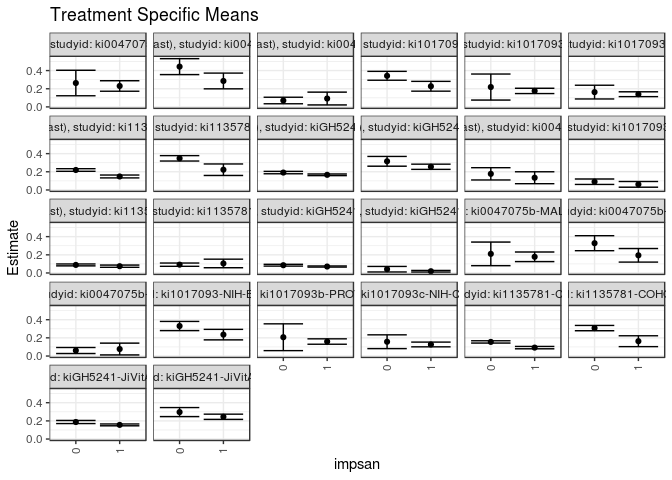

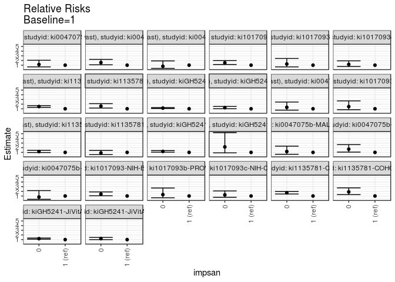

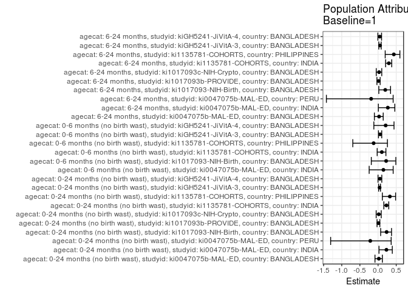

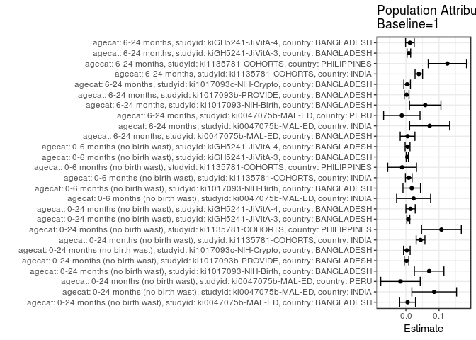

## Results Table

### Parameter: TSM

| agecat | studyid | country | intervention_level | baseline_level | estimate | ci_lower | ci_upper |
| --- | --- | --- | --- | --- | --- | --- | --- |
| 0-24 months (no birth wast) | ki0047075b-MAL-ED | BANGLADESH | 1 | NA | 0.2303922 | 0.1724892 | 0.2882951 |
| 0-24 months (no birth wast) | ki0047075b-MAL-ED | BANGLADESH | 0 | NA | 0.2631579 | 0.1228601 | 0.4034557 |
| 0-24 months (no birth wast) | ki0047075b-MAL-ED | INDIA | 1 | NA | 0.2857143 | 0.1991167 | 0.3723119 |
| 0-24 months (no birth wast) | ki0047075b-MAL-ED | INDIA | 0 | NA | 0.4435484 | 0.3559146 | 0.5311822 |
| 0-24 months (no birth wast) | ki0047075b-MAL-ED | PERU | 1 | NA | 0.0923077 | 0.0218048 | 0.1628106 |
| 0-24 months (no birth wast) | ki0047075b-MAL-ED | PERU | 0 | NA | 0.0707071 | 0.0349345 | 0.1064797 |
| 0-24 months (no birth wast) | ki1017093-NIH-Birth | BANGLADESH | 1 | NA | 0.2274678 | 0.1735972 | 0.2813384 |
| 0-24 months (no birth wast) | ki1017093-NIH-Birth | BANGLADESH | 0 | NA | 0.3424658 | 0.2937429 | 0.3911886 |
| 0-24 months (no birth wast) | ki1017093b-PROVIDE | BANGLADESH | 1 | NA | 0.1761103 | 0.1468731 | 0.2053474 |
| 0-24 months (no birth wast) | ki1017093b-PROVIDE | BANGLADESH | 0 | NA | 0.2187500 | 0.0754126 | 0.3620874 |
| 0-24 months (no birth wast) | ki1017093c-NIH-Crypto | BANGLADESH | 1 | NA | 0.1397849 | 0.1131296 | 0.1664403 |
| 0-24 months (no birth wast) | ki1017093c-NIH-Crypto | BANGLADESH | 0 | NA | 0.1630435 | 0.0875082 | 0.2385788 |
| 0-24 months (no birth wast) | ki1135781-COHORTS | INDIA | 1 | NA | 0.1483180 | 0.1325899 | 0.1640461 |
| 0-24 months (no birth wast) | ki1135781-COHORTS | INDIA | 0 | NA | 0.2197871 | 0.2054246 | 0.2341496 |
| 0-24 months (no birth wast) | ki1135781-COHORTS | PHILIPPINES | 1 | NA | 0.2228916 | 0.1595528 | 0.2862303 |
| 0-24 months (no birth wast) | ki1135781-COHORTS | PHILIPPINES | 0 | NA | 0.3481332 | 0.3184609 | 0.3778055 |
| 0-24 months (no birth wast) | kiGH5241-JiVitA-3 | BANGLADESH | 1 | NA | 0.1666667 | 0.1578338 | 0.1754996 |
| 0-24 months (no birth wast) | kiGH5241-JiVitA-3 | BANGLADESH | 0 | NA | 0.1913564 | 0.1779555 | 0.2047574 |
| 0-24 months (no birth wast) | kiGH5241-JiVitA-4 | BANGLADESH | 1 | NA | 0.2552995 | 0.2264954 | 0.2841036 |
| 0-24 months (no birth wast) | kiGH5241-JiVitA-4 | BANGLADESH | 0 | NA | 0.3153153 | 0.2615317 | 0.3690989 |
| 0-6 months (no birth wast) | ki0047075b-MAL-ED | INDIA | 1 | NA | 0.1346154 | 0.0688742 | 0.2003566 |
| 0-6 months (no birth wast) | ki0047075b-MAL-ED | INDIA | 0 | NA | 0.1774194 | 0.1100315 | 0.2448072 |
| 0-6 months (no birth wast) | ki1017093-NIH-Birth | BANGLADESH | 1 | NA | 0.0616740 | 0.0303528 | 0.0929952 |
| 0-6 months (no birth wast) | ki1017093-NIH-Birth | BANGLADESH | 0 | NA | 0.0906516 | 0.0606746 | 0.1206286 |
| 0-6 months (no birth wast) | ki1135781-COHORTS | INDIA | 1 | NA | 0.0748571 | 0.0625262 | 0.0871881 |
| 0-6 months (no birth wast) | ki1135781-COHORTS | INDIA | 0 | NA | 0.0888112 | 0.0783844 | 0.0992380 |
| 0-6 months (no birth wast) | ki1135781-COHORTS | PHILIPPINES | 1 | NA | 0.1049383 | 0.0577239 | 0.1521526 |
| 0-6 months (no birth wast) | ki1135781-COHORTS | PHILIPPINES | 0 | NA | 0.0916497 | 0.0735957 | 0.1097037 |
| 0-6 months (no birth wast) | kiGH5241-JiVitA-3 | BANGLADESH | 1 | NA | 0.0709463 | 0.0648162 | 0.0770764 |
| 0-6 months (no birth wast) | kiGH5241-JiVitA-3 | BANGLADESH | 0 | NA | 0.0855333 | 0.0756404 | 0.0954262 |
| 0-6 months (no birth wast) | kiGH5241-JiVitA-4 | BANGLADESH | 1 | NA | 0.0192503 | 0.0104359 | 0.0280646 |
| 0-6 months (no birth wast) | kiGH5241-JiVitA-4 | BANGLADESH | 0 | NA | 0.0418118 | 0.0113104 | 0.0723133 |
| 6-24 months | ki0047075b-MAL-ED | BANGLADESH | 1 | NA | 0.1782178 | 0.1253328 | 0.2311029 |
| 6-24 months | ki0047075b-MAL-ED | BANGLADESH | 0 | NA | 0.2105263 | 0.0806335 | 0.3404191 |
| 6-24 months | ki0047075b-MAL-ED | INDIA | 1 | NA | 0.1944444 | 0.1196420 | 0.2692469 |
| 6-24 months | ki0047075b-MAL-ED | INDIA | 0 | NA | 0.3280000 | 0.2455200 | 0.4104800 |
| 6-24 months | ki0047075b-MAL-ED | PERU | 1 | NA | 0.0769231 | 0.0120199 | 0.1418262 |
| 6-24 months | ki0047075b-MAL-ED | PERU | 0 | NA | 0.0606061 | 0.0273076 | 0.0939046 |
| 6-24 months | ki1017093-NIH-Birth | BANGLADESH | 1 | NA | 0.2355769 | 0.1778536 | 0.2933003 |
| 6-24 months | ki1017093-NIH-Birth | BANGLADESH | 0 | NA | 0.3303303 | 0.2797674 | 0.3808933 |
| 6-24 months | ki1017093b-PROVIDE | BANGLADESH | 1 | NA | 0.1592466 | 0.1295460 | 0.1889472 |
| 6-24 months | ki1017093b-PROVIDE | BANGLADESH | 0 | NA | 0.2068966 | 0.0593445 | 0.3544486 |
| 6-24 months | ki1017093c-NIH-Crypto | BANGLADESH | 1 | NA | 0.1269841 | 0.1009666 | 0.1530016 |
| 6-24 months | ki1017093c-NIH-Crypto | BANGLADESH | 0 | NA | 0.1573034 | 0.0816096 | 0.2329971 |
| 6-24 months | ki1135781-COHORTS | INDIA | 1 | NA | 0.0924856 | 0.0794678 | 0.1055033 |
| 6-24 months | ki1135781-COHORTS | INDIA | 0 | NA | 0.1553491 | 0.1426414 | 0.1680569 |
| 6-24 months | ki1135781-COHORTS | PHILIPPINES | 1 | NA | 0.1632653 | 0.1034895 | 0.2230411 |
| 6-24 months | ki1135781-COHORTS | PHILIPPINES | 0 | NA | 0.3074534 | 0.2783416 | 0.3365652 |
| 6-24 months | kiGH5241-JiVitA-3 | BANGLADESH | 1 | NA | 0.1559140 | 0.1457289 | 0.1660991 |
| 6-24 months | kiGH5241-JiVitA-3 | BANGLADESH | 0 | NA | 0.1875519 | 0.1704519 | 0.2046519 |
| 6-24 months | kiGH5241-JiVitA-4 | BANGLADESH | 1 | NA | 0.2451967 | 0.2163987 | 0.2739947 |
| 6-24 months | kiGH5241-JiVitA-4 | BANGLADESH | 0 | NA | 0.2967359 | 0.2471076 | 0.3463642 |

### Parameter: E(Y)

| agecat | studyid | country | intervention_level | baseline_level | estimate | ci_lower | ci_upper |
| --- | --- | --- | --- | --- | --- | --- | --- |
| 0-24 months (no birth wast) | ki0047075b-MAL-ED | BANGLADESH | NA | NA | 0.2355372 | 0.1819640 | 0.2891104 |
| 0-24 months (no birth wast) | ki0047075b-MAL-ED | INDIA | NA | NA | 0.3711790 | 0.3084692 | 0.4338889 |
| 0-24 months (no birth wast) | ki0047075b-MAL-ED | PERU | NA | NA | 0.0760456 | 0.0439490 | 0.1081423 |
| 0-24 months (no birth wast) | ki1017093-NIH-Birth | BANGLADESH | NA | NA | 0.2976589 | 0.2609818 | 0.3343359 |
| 0-24 months (no birth wast) | ki1017093b-PROVIDE | BANGLADESH | NA | NA | 0.1781022 | 0.1494298 | 0.2067746 |
| 0-24 months (no birth wast) | ki1017093c-NIH-Crypto | BANGLADESH | NA | NA | 0.1426649 | 0.1175009 | 0.1678289 |
| 0-24 months (no birth wast) | ki1135781-COHORTS | INDIA | NA | NA | 0.1925912 | 0.1818265 | 0.2033558 |
| 0-24 months (no birth wast) | ki1135781-COHORTS | PHILIPPINES | NA | NA | 0.3301642 | 0.3030549 | 0.3572735 |
| 0-24 months (no birth wast) | kiGH5241-JiVitA-3 | BANGLADESH | NA | NA | 0.1739632 | 0.1661367 | 0.1817897 |
| 0-24 months (no birth wast) | kiGH5241-JiVitA-4 | BANGLADESH | NA | NA | 0.2693935 | 0.2426940 | 0.2960930 |
| 0-6 months (no birth wast) | ki0047075b-MAL-ED | INDIA | NA | NA | 0.1578947 | 0.1104594 | 0.2053301 |
| 0-6 months (no birth wast) | ki1017093-NIH-Birth | BANGLADESH | NA | NA | 0.0793103 | 0.0572998 | 0.1013209 |
| 0-6 months (no birth wast) | ki1135781-COHORTS | INDIA | NA | NA | 0.0835141 | 0.0755270 | 0.0915012 |
| 0-6 months (no birth wast) | ki1135781-COHORTS | PHILIPPINES | NA | NA | 0.0935315 | 0.0766512 | 0.1104118 |
| 0-6 months (no birth wast) | kiGH5241-JiVitA-3 | BANGLADESH | NA | NA | 0.0752554 | 0.0699632 | 0.0805476 |
| 0-6 months (no birth wast) | kiGH5241-JiVitA-4 | BANGLADESH | NA | NA | 0.0243328 | 0.0149179 | 0.0337477 |
| 6-24 months | ki0047075b-MAL-ED | BANGLADESH | NA | NA | 0.1833333 | 0.1342773 | 0.2323893 |
| 6-24 months | ki0047075b-MAL-ED | INDIA | NA | NA | 0.2660944 | 0.2092298 | 0.3229590 |
| 6-24 months | ki0047075b-MAL-ED | PERU | NA | NA | 0.0646388 | 0.0348650 | 0.0944125 |
| 6-24 months | ki1017093-NIH-Birth | BANGLADESH | NA | NA | 0.2939002 | 0.2554778 | 0.3323226 |
| 6-24 months | ki1017093b-PROVIDE | BANGLADESH | NA | NA | 0.1615008 | 0.1323459 | 0.1906557 |
| 6-24 months | ki1017093c-NIH-Crypto | BANGLADESH | NA | NA | 0.1307371 | 0.1060790 | 0.1553953 |
| 6-24 months | ki1135781-COHORTS | INDIA | NA | NA | 0.1315423 | 0.1221962 | 0.1408884 |
| 6-24 months | ki1135781-COHORTS | PHILIPPINES | NA | NA | 0.2884097 | 0.2617831 | 0.3150363 |
| 6-24 months | kiGH5241-JiVitA-3 | BANGLADESH | NA | NA | 0.1648339 | 0.1556475 | 0.1740202 |
| 6-24 months | kiGH5241-JiVitA-4 | BANGLADESH | NA | NA | 0.2573427 | 0.2311603 | 0.2835250 |

### Parameter: RR

| agecat | studyid | country | intervention_level | baseline_level | estimate | ci_lower | ci_upper |
| --- | --- | --- | --- | --- | --- | --- | --- |
| 0-24 months (no birth wast) | ki0047075b-MAL-ED | BANGLADESH | 1 | 1 | 1.0000000 | 1.0000000 | 1.000000 |
| 0-24 months (no birth wast) | ki0047075b-MAL-ED | BANGLADESH | 0 | 1 | 1.1422172 | 0.6335419 | 2.059312 |
| 0-24 months (no birth wast) | ki0047075b-MAL-ED | INDIA | 1 | 1 | 1.0000000 | 1.0000000 | 1.000000 |
| 0-24 months (no birth wast) | ki0047075b-MAL-ED | INDIA | 0 | 1 | 1.5524194 | 1.0811371 | 2.229140 |
| 0-24 months (no birth wast) | ki0047075b-MAL-ED | PERU | 1 | 1 | 1.0000000 | 1.0000000 | 1.000000 |
| 0-24 months (no birth wast) | ki0047075b-MAL-ED | PERU | 0 | 1 | 0.7659933 | 0.3064416 | 1.914706 |
| 0-24 months (no birth wast) | ki1017093-NIH-Birth | BANGLADESH | 1 | 1 | 1.0000000 | 1.0000000 | 1.000000 |
| 0-24 months (no birth wast) | ki1017093-NIH-Birth | BANGLADESH | 0 | 1 | 1.5055570 | 1.1421214 | 1.984642 |
| 0-24 months (no birth wast) | ki1017093b-PROVIDE | BANGLADESH | 1 | 1 | 1.0000000 | 1.0000000 | 1.000000 |
| 0-24 months (no birth wast) | ki1017093b-PROVIDE | BANGLADESH | 0 | 1 | 1.2421196 | 0.6318260 | 2.441908 |
| 0-24 months (no birth wast) | ki1017093c-NIH-Crypto | BANGLADESH | 1 | 1 | 1.0000000 | 1.0000000 | 1.000000 |
| 0-24 months (no birth wast) | ki1017093c-NIH-Crypto | BANGLADESH | 0 | 1 | 1.1663880 | 0.7067486 | 1.924957 |
| 0-24 months (no birth wast) | ki1135781-COHORTS | INDIA | 1 | 1 | 1.0000000 | 1.0000000 | 1.000000 |
| 0-24 months (no birth wast) | ki1135781-COHORTS | INDIA | 0 | 1 | 1.4818635 | 1.3083143 | 1.678434 |
| 0-24 months (no birth wast) | ki1135781-COHORTS | PHILIPPINES | 1 | 1 | 1.0000000 | 1.0000000 | 1.000000 |
| 0-24 months (no birth wast) | ki1135781-COHORTS | PHILIPPINES | 0 | 1 | 1.5618949 | 1.1609334 | 2.101340 |
| 0-24 months (no birth wast) | kiGH5241-JiVitA-3 | BANGLADESH | 1 | 1 | 1.0000000 | 1.0000000 | 1.000000 |
| 0-24 months (no birth wast) | kiGH5241-JiVitA-3 | BANGLADESH | 0 | 1 | 1.1481385 | 1.0581302 | 1.245803 |
| 0-24 months (no birth wast) | kiGH5241-JiVitA-4 | BANGLADESH | 1 | 1 | 1.0000000 | 1.0000000 | 1.000000 |
| 0-24 months (no birth wast) | kiGH5241-JiVitA-4 | BANGLADESH | 0 | 1 | 1.2350798 | 1.0152585 | 1.502496 |
| 0-6 months (no birth wast) | ki0047075b-MAL-ED | INDIA | 1 | 1 | 1.0000000 | 1.0000000 | 1.000000 |
| 0-6 months (no birth wast) | ki0047075b-MAL-ED | INDIA | 0 | 1 | 1.3179724 | 0.7099330 | 2.446782 |
| 0-6 months (no birth wast) | ki1017093-NIH-Birth | BANGLADESH | 1 | 1 | 1.0000000 | 1.0000000 | 1.000000 |
| 0-6 months (no birth wast) | ki1017093-NIH-Birth | BANGLADESH | 0 | 1 | 1.4698503 | 0.8018271 | 2.694421 |
| 0-6 months (no birth wast) | ki1135781-COHORTS | INDIA | 1 | 1 | 1.0000000 | 1.0000000 | 1.000000 |
| 0-6 months (no birth wast) | ki1135781-COHORTS | INDIA | 0 | 1 | 1.1864090 | 0.9691341 | 1.452396 |
| 0-6 months (no birth wast) | ki1135781-COHORTS | PHILIPPINES | 1 | 1 | 1.0000000 | 1.0000000 | 1.000000 |
| 0-6 months (no birth wast) | ki1135781-COHORTS | PHILIPPINES | 0 | 1 | 0.8733677 | 0.5344282 | 1.427266 |
| 0-6 months (no birth wast) | kiGH5241-JiVitA-3 | BANGLADESH | 1 | 1 | 1.0000000 | 1.0000000 | 1.000000 |
| 0-6 months (no birth wast) | kiGH5241-JiVitA-3 | BANGLADESH | 0 | 1 | 1.2056054 | 1.0460940 | 1.389439 |
| 0-6 months (no birth wast) | kiGH5241-JiVitA-4 | BANGLADESH | 1 | 1 | 1.0000000 | 1.0000000 | 1.000000 |
| 0-6 months (no birth wast) | kiGH5241-JiVitA-4 | BANGLADESH | 0 | 1 | 2.1720154 | 0.9004039 | 5.239483 |
| 6-24 months | ki0047075b-MAL-ED | BANGLADESH | 1 | 1 | 1.0000000 | 1.0000000 | 1.000000 |
| 6-24 months | ki0047075b-MAL-ED | BANGLADESH | 0 | 1 | 1.1812865 | 0.5956883 | 2.342564 |
| 6-24 months | ki0047075b-MAL-ED | INDIA | 1 | 1 | 1.0000000 | 1.0000000 | 1.000000 |
| 6-24 months | ki0047075b-MAL-ED | INDIA | 0 | 1 | 1.6868571 | 1.0653179 | 2.671022 |
| 6-24 months | ki0047075b-MAL-ED | PERU | 1 | 1 | 1.0000000 | 1.0000000 | 1.000000 |
| 6-24 months | ki0047075b-MAL-ED | PERU | 0 | 1 | 0.7878788 | 0.2878628 | 2.156419 |
| 6-24 months | ki1017093-NIH-Birth | BANGLADESH | 1 | 1 | 1.0000000 | 1.0000000 | 1.000000 |
| 6-24 months | ki1017093-NIH-Birth | BANGLADESH | 0 | 1 | 1.4022185 | 1.0503728 | 1.871923 |
| 6-24 months | ki1017093b-PROVIDE | BANGLADESH | 1 | 1 | 1.0000000 | 1.0000000 | 1.000000 |
| 6-24 months | ki1017093b-PROVIDE | BANGLADESH | 0 | 1 | 1.2992214 | 0.6216443 | 2.715341 |
| 6-24 months | ki1017093c-NIH-Crypto | BANGLADESH | 1 | 1 | 1.0000000 | 1.0000000 | 1.000000 |
| 6-24 months | ki1017093c-NIH-Crypto | BANGLADESH | 0 | 1 | 1.2387640 | 0.7342649 | 2.089895 |
| 6-24 months | ki1135781-COHORTS | INDIA | 1 | 1 | 1.0000000 | 1.0000000 | 1.000000 |
| 6-24 months | ki1135781-COHORTS | INDIA | 0 | 1 | 1.6797124 | 1.4273571 | 1.976684 |
| 6-24 months | ki1135781-COHORTS | PHILIPPINES | 1 | 1 | 1.0000000 | 1.0000000 | 1.000000 |
| 6-24 months | ki1135781-COHORTS | PHILIPPINES | 0 | 1 | 1.8831522 | 1.2901707 | 2.748677 |
| 6-24 months | kiGH5241-JiVitA-3 | BANGLADESH | 1 | 1 | 1.0000000 | 1.0000000 | 1.000000 |
| 6-24 months | kiGH5241-JiVitA-3 | BANGLADESH | 0 | 1 | 1.2029189 | 1.0813621 | 1.338140 |
| 6-24 months | kiGH5241-JiVitA-4 | BANGLADESH | 1 | 1 | 1.0000000 | 1.0000000 | 1.000000 |
| 6-24 months | kiGH5241-JiVitA-4 | BANGLADESH | 0 | 1 | 1.2101953 | 0.9958029 | 1.470746 |

### Parameter: PAR

| agecat | studyid | country | intervention_level | baseline_level | estimate | ci_lower | ci_upper |
| --- | --- | --- | --- | --- | --- | --- | --- |
| 0-24 months (no birth wast) | ki0047075b-MAL-ED | BANGLADESH | 1 | NA | 0.0051450 | -0.0187352 | 0.0290252 |
| 0-24 months (no birth wast) | ki0047075b-MAL-ED | INDIA | 1 | NA | 0.0854648 | 0.0179760 | 0.1529535 |
| 0-24 months (no birth wast) | ki0047075b-MAL-ED | PERU | 1 | NA | -0.0162621 | -0.0757925 | 0.0432684 |
| 0-24 months (no birth wast) | ki1017093-NIH-Birth | BANGLADESH | 1 | NA | 0.0701911 | 0.0256288 | 0.1147533 |
| 0-24 months (no birth wast) | ki1017093b-PROVIDE | BANGLADESH | 1 | NA | 0.0019919 | -0.0048752 | 0.0088590 |
| 0-24 months (no birth wast) | ki1017093c-NIH-Crypto | BANGLADESH | 1 | NA | 0.0028799 | -0.0070536 | 0.0128135 |
| 0-24 months (no birth wast) | ki1135781-COHORTS | INDIA | 1 | NA | 0.0442731 | 0.0310449 | 0.0575013 |
| 0-24 months (no birth wast) | ki1135781-COHORTS | PHILIPPINES | 1 | NA | 0.1072727 | 0.0473099 | 0.1672354 |
| 0-24 months (no birth wast) | kiGH5241-JiVitA-3 | BANGLADESH | 1 | NA | 0.0072966 | 0.0028409 | 0.0117522 |
| 0-24 months (no birth wast) | kiGH5241-JiVitA-4 | BANGLADESH | 1 | NA | 0.0140940 | 0.0000361 | 0.0281518 |
| 0-6 months (no birth wast) | ki0047075b-MAL-ED | INDIA | 1 | NA | 0.0232794 | -0.0279966 | 0.0745554 |
| 0-6 months (no birth wast) | ki1017093-NIH-Birth | BANGLADESH | 1 | NA | 0.0176363 | -0.0087754 | 0.0440481 |
| 0-6 months (no birth wast) | ki1135781-COHORTS | INDIA | 1 | NA | 0.0086570 | -0.0013633 | 0.0186772 |
| 0-6 months (no birth wast) | ki1135781-COHORTS | PHILIPPINES | 1 | NA | -0.0114068 | -0.0547980 | 0.0319844 |
| 0-6 months (no birth wast) | kiGH5241-JiVitA-3 | BANGLADESH | 1 | NA | 0.0043091 | 0.0009124 | 0.0077058 |
| 0-6 months (no birth wast) | kiGH5241-JiVitA-4 | BANGLADESH | 1 | NA | 0.0050826 | -0.0022250 | 0.0123901 |
| 6-24 months | ki0047075b-MAL-ED | BANGLADESH | 1 | NA | 0.0051155 | -0.0171404 | 0.0273714 |
| 6-24 months | ki0047075b-MAL-ED | INDIA | 1 | NA | 0.0716500 | 0.0113024 | 0.1319976 |
| 6-24 months | ki0047075b-MAL-ED | PERU | 1 | NA | -0.0122843 | -0.0672089 | 0.0426403 |
| 6-24 months | ki1017093-NIH-Birth | BANGLADESH | 1 | NA | 0.0583233 | 0.0109297 | 0.1057168 |
| 6-24 months | ki1017093b-PROVIDE | BANGLADESH | 1 | NA | 0.0022542 | -0.0049112 | 0.0094197 |
| 6-24 months | ki1017093c-NIH-Crypto | BANGLADESH | 1 | NA | 0.0037530 | -0.0061815 | 0.0136875 |
| 6-24 months | ki1135781-COHORTS | INDIA | 1 | NA | 0.0390567 | 0.0277228 | 0.0503907 |
| 6-24 months | ki1135781-COHORTS | PHILIPPINES | 1 | NA | 0.1251444 | 0.0673666 | 0.1829222 |
| 6-24 months | kiGH5241-JiVitA-3 | BANGLADESH | 1 | NA | 0.0089199 | 0.0035274 | 0.0143124 |
| 6-24 months | kiGH5241-JiVitA-4 | BANGLADESH | 1 | NA | 0.0121460 | -0.0009355 | 0.0252274 |

### Parameter: PAF

| agecat | studyid | country | intervention_level | baseline_level | estimate | ci_lower | ci_upper |
| --- | --- | --- | --- | --- | --- | --- | --- |
| 0-24 months (no birth wast) | ki0047075b-MAL-ED | BANGLADESH | 1 | NA | 0.0218438 | -0.0849294 | 0.1181090 |
| 0-24 months (no birth wast) | ki0047075b-MAL-ED | INDIA | 1 | NA | 0.2302521 | 0.0256412 | 0.3918957 |
| 0-24 months (no birth wast) | ki0047075b-MAL-ED | PERU | 1 | NA | -0.2138462 | -1.3054314 | 0.3608908 |
| 0-24 months (no birth wast) | ki1017093-NIH-Birth | BANGLADESH | 1 | NA | 0.2358104 | 0.0716420 | 0.3709477 |
| 0-24 months (no birth wast) | ki1017093b-PROVIDE | BANGLADESH | 1 | NA | 0.0111842 | -0.0281096 | 0.0489762 |
| 0-24 months (no birth wast) | ki1017093c-NIH-Crypto | BANGLADESH | 1 | NA | 0.0201867 | -0.0519095 | 0.0873415 |
| 0-24 months (no birth wast) | ki1135781-COHORTS | INDIA | 1 | NA | 0.2298813 | 0.1588752 | 0.2948933 |
| 0-24 months (no birth wast) | ki1135781-COHORTS | PHILIPPINES | 1 | NA | 0.3249070 | 0.1173754 | 0.4836416 |
| 0-24 months (no birth wast) | kiGH5241-JiVitA-3 | BANGLADESH | 1 | NA | 0.0419431 | 0.0159996 | 0.0672026 |
| 0-24 months (no birth wast) | kiGH5241-JiVitA-4 | BANGLADESH | 1 | NA | 0.0523174 | -0.0010110 | 0.1028048 |
| 0-6 months (no birth wast) | ki0047075b-MAL-ED | INDIA | 1 | NA | 0.1474359 | -0.2448096 | 0.4160830 |
| 0-6 months (no birth wast) | ki1017093-NIH-Birth | BANGLADESH | 1 | NA | 0.2223712 | -0.1856904 | 0.4899963 |
| 0-6 months (no birth wast) | ki1135781-COHORTS | INDIA | 1 | NA | 0.1036586 | -0.0243324 | 0.2156571 |
| 0-6 months (no birth wast) | ki1135781-COHORTS | PHILIPPINES | 1 | NA | -0.1219568 | -0.6958920 | 0.2577433 |
| 0-6 months (no birth wast) | kiGH5241-JiVitA-3 | BANGLADESH | 1 | NA | 0.0572594 | 0.0110688 | 0.1012926 |
| 0-6 months (no birth wast) | kiGH5241-JiVitA-4 | BANGLADESH | 1 | NA | 0.2088767 | -0.1158288 | 0.4390931 |
| 6-24 months | ki0047075b-MAL-ED | BANGLADESH | 1 | NA | 0.0279028 | -0.1012521 | 0.1419104 |
| 6-24 months | ki0047075b-MAL-ED | INDIA | 1 | NA | 0.2692652 | 0.0080455 | 0.4616958 |
| 6-24 months | ki0047075b-MAL-ED | PERU | 1 | NA | -0.1900452 | -1.4225929 | 0.4154166 |
| 6-24 months | ki1017093-NIH-Birth | BANGLADESH | 1 | NA | 0.1984458 | 0.0206735 | 0.3439480 |
| 6-24 months | ki1017093b-PROVIDE | BANGLADESH | 1 | NA | 0.0139581 | -0.0313765 | 0.0572999 |
| 6-24 months | ki1017093c-NIH-Crypto | BANGLADESH | 1 | NA | 0.0287065 | -0.0501857 | 0.1016722 |
| 6-24 months | ki1135781-COHORTS | INDIA | 1 | NA | 0.2969139 | 0.2075716 | 0.3761833 |
| 6-24 months | ki1135781-COHORTS | PHILIPPINES | 1 | NA | 0.4339119 | 0.1966511 | 0.6011001 |
| 6-24 months | kiGH5241-JiVitA-3 | BANGLADESH | 1 | NA | 0.0541145 | 0.0209904 | 0.0861179 |
| 6-24 months | kiGH5241-JiVitA-4 | BANGLADESH | 1 | NA | 0.0471976 | -0.0050529 | 0.0967317 |